# Assignment 6: Establishing a topic for your meta-analysis

Modern Research Methods

**Objectives**

By the end of this assignment, you should:

- know the topic of your final project meta-analysis.
- know who the other members of your group are.
- understand the details of the paradigm of your meta-analysis.
- have the “meat” of the introduction for your final paper written.

This assignment is due **Thursday, April 2 at noon**. This assignment, unlike previous assignments, is focused on writing. Revised versions of the paragraphs you write as part of this assignment will later be included in the introduction to your final paper.

Because this assignment does not involve R code, you will write-up your answers in a google doc, rather than a .Rmd file. A template is provided [here](https://docs.google.com/document/d/1up1zCvjW6s8ElKrE9ezgCcErzc95di9e-cRrH5h3YPY/edit). Copy and paste this template to a new document and write your answers in that document. When you’re ready to submit your assignment on Canvas, provide a link to your google docs in the “comments” field, and attach the seminal paper that your meta-analysis will build off of, as below:

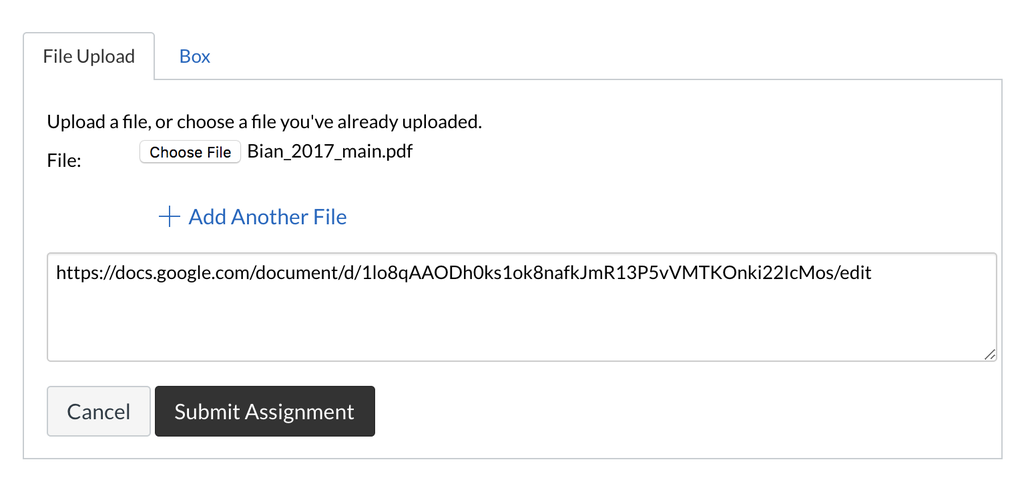

1. What is the seminal paper your meta-analysis will build off of? (write the name of the paper from the [Google Drive folder](https://drive.google.com/drive/u/0/folders/1G6TOX6HlHiIaJLnOTt8Qf4UNV-mAhQ7I)).
1. Details about your group.  
   **[a]** Who are the other members of your group?  
   **[b]** Discuss with your group the best way to work together in the future. Is everyone able to work together via Zoom? Is there a better a way to work together? Tell me what you decide.
1. Set up a time to meet with me with all your group members next week. In the meeting, we’ll discuss your project, and how to go about calculating effect sizes for your meta-analysis. In your assignment, record the date you met with me and what we discussed (very briefly).
1. **[a]** Read the seminal paper in detail. It is important that you understand the ins and outs of this paper.  
   **[b]** Watch [this video](https://www.youtube.com/watch?v=0TVSjaRsfGU&list=PLu8FqtGdUsEJUqHmhEo2Kq-e7qJ07ocUi&index=2) to help you think about the topic of your meta-analysis.
2. What is the general question this paper is asking, and why is this question important? Your answer to this should be *general*. For example, in the mutual exclusivity case, the general question would have to do with understanding how children learn new words; the specific question would have to do with how often children select the novel object when presented with a novel label and a novel and familiar object. [~1 paragraph]
3. What is the specific question this paper is asking? Are there factors that you think might affect peformance in this task (i.e. moderators) [~1 paragraph]
3. Describe the method of th experiments in the seminal paper. If there is more than one experiment, focus on the one that is most relevant for your meta-analysis. Your description should include information about (i) the paradigm used, (ii) who the participants were, (iii) what the dependent measure(s) was, and what the (iii) independent measure was. [~1 paragraph]
3. What did they find? Concisely describe the pattern of results *that is relevant for the meta-analysis*. [~1 paragraph]
3. **Extra credit**: Use Google Scholar to find one additional paper in the literature that uses the same paradigm as the one in your seminal paper. Highlight the relevant methods and results section. Submit a pdf of that paper along with your assignment. In your assignment, write the name of the paper.